# Dixon_Homework2_Q2

Jerome Dixon

2/25/2021

2. A manufacturer is interested in the proportion 𝜃 of defective parts supplied by a supplier.
1. (5 pts) The supplier claims that they maintain a 95% or better acceptable part rate. Assuming that they are correct 90% of the time, what are the values of 𝛼 and 𝛽 that meets this requirement.

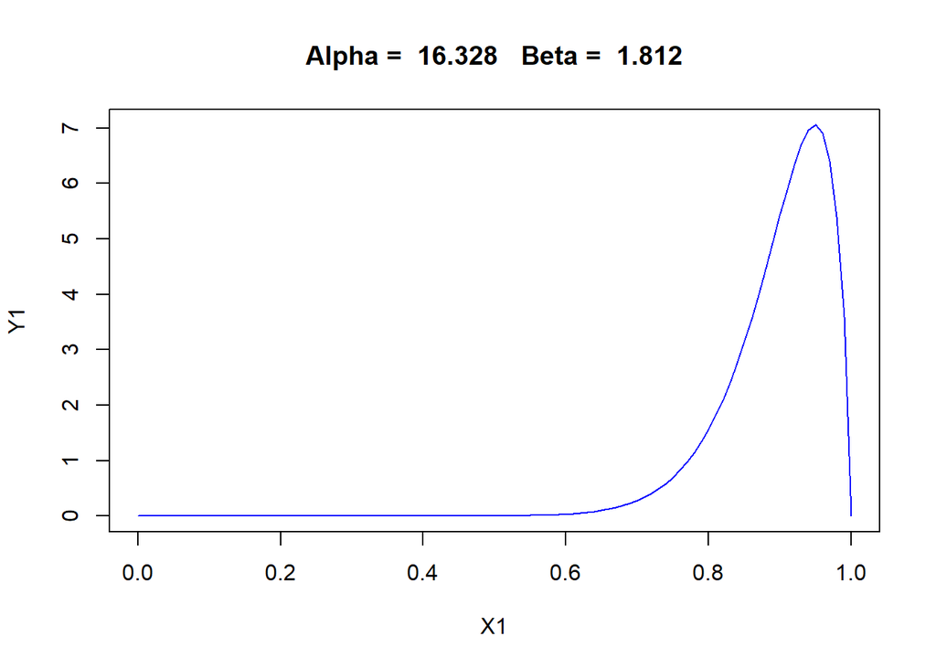

```r
# 𝜃~ 0 < .9 < .95
# Mean = alpha/(alpha + beta) => .9 = x1/(x1+x2)
# Maximum = (alpha - 1) / (alpha + beta -2) => .95 = x1-1/(x1 + x2 -2)
# Put in matrix format and solve for system of equations

A <- cbind(c(.111, .053),c(-1, -1))

b <- cbind(c(0, -.947))

alpha_Beta1 <- solve(A,b)

X1 <- seq(0, 1, by=0.01)

Y1 <- dbeta(X1, alpha_Beta1[1], alpha_Beta1[2])

plot(X1, Y1, type= 'l', col = 'blue',
     main = paste("Alpha = ", round(alpha_Beta1[1],3), " ", "Beta = ", round(alpha_Beta1[2],3) ))
```

2. (5 pts) The manufacturer believes that this claim is only correct 50% of the time, what are the values of 𝛼 and 𝛽 that meets this requirement.

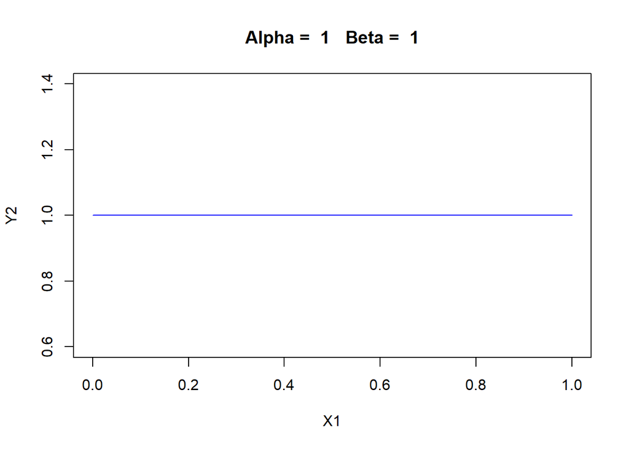

```r
# 𝜃~ 0 < .9 < .95
# Mean = alpha/(alpha + beta) => .5 = x1/(x1+x2)
# Maximum = (alpha - 1) / (alpha + beta -2) => .95 = x1-1/(x1 + x2 -2)
# Put in matrix format and solve for system of equations

A <- cbind(c(1, .053),c(-1, -1))

b <- cbind(c(0, -.947))

alpha_Beta2 <- solve(A,b)

X1 <- seq(0, 1, by=0.01)

Y2 <- dbeta(X1, alpha_Beta2[1], alpha_Beta2[2])

plot(X1, Y2, type= 'l', col = 'blue',
     main = paste("Alpha = ", round(alpha_Beta2[1],3), " ", "Beta = ", round(alpha_Beta2[2],3) ))
```

3. (5 pts) Plot the two prior distributions for 𝜃 on the same plot.

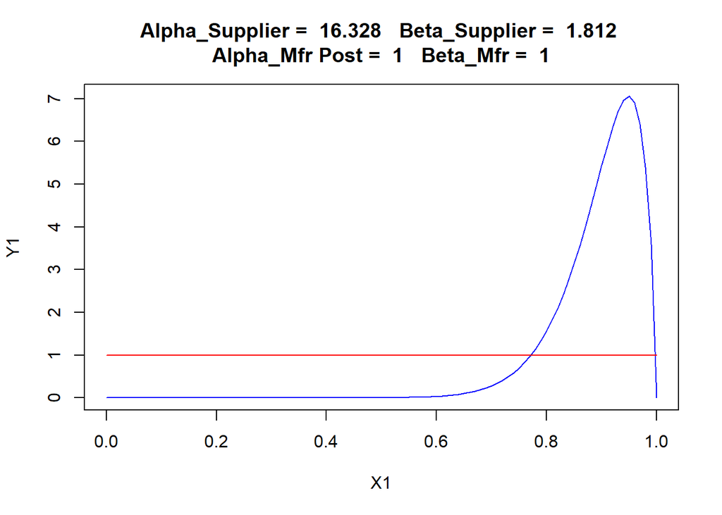

```r
plot(X1, Y1, type= 'l', col = 'blue',
     main = paste("Alpha_Supplier = ", round(alpha_Beta1[1],3), " ", "Beta_Supplier = ", round(alpha_Beta1[2],3),
     sub = paste("\nAlpha_Mfr Post = ", round(alpha_Beta2[1],3), " ", "Beta_Mfr = ", round(alpha_Beta2[1],3) )))
lines(X1, Y2, col = 'red')
```

4. (5 pts) The manufacturer sends a quality engineer to take samples from a bin of parts for the recent shipment. He samples parts until he obtains 3 defective parts and counts the number of acceptable parts until the 3 defectives are obtained. What is the random variable and what is the likelihood for this experiment?

Random variable = # of independent trials until the first successful defect

Likelihood = (1-p)^x * p for x=0,2,3,4,5,..

5. (5 pts) Find the posterior distribution for 𝜃 using the prior distributions from items a. and b. above.

```r
x = 3
p1 = .1
p2 = .5

posterior_distro1 = dgeom(x, p1)

posterior_distro2 = dgeom(x, p2)

posterior_distro1 ; posterior_distro2
```

```
## [1] 0.0729
```

```
## [1] 0.0625
```

6. (5 pts) Find the posterior means and standard deviations for 𝜃 for items a. and b. above. Note you should have two answers.

```r
mean1 = (1-p1)/p1
mean2 = (1-p2)/p2


mean1; mean2
```

```
## [1] 9
```

```
## [1] 1
```

```r
sd1 = sqrt((1-p1)/p1^2)
sd2 = sqrt((1-p2)/p2^2)

mean1; mean2
```

```
## [1] 9
```

```
## [1] 1
```

```r
sd1; sd2
```

```
## [1] 9.486833
```

```
## [1] 1.414214
```

7. (5 pts) Find 95% credible intervals for 𝜃 for items a. and b. above. Note you should have two answers. Be sure to interpret the intervals.

```r
cred_interval1 <- qgeom(c(0.05,.95), p1)

cred_interval2 <- qgeom(c(0.05,.95), p2)

cred_interval1; cred_interval2
```

```
## [1]  0 28
```

```
## [1] 0 4
```

8. (5 pts) Create plots with the prior and posterior distributions for 𝜃 for each of the items a. and b. above. You should have two plots here.

```r
g1 <- dgeom(X1, posterior_distro1)
```

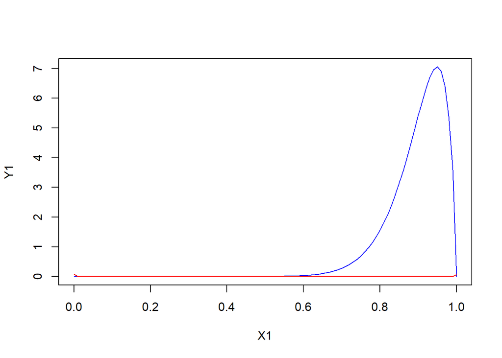

```r
plot(X1, Y1, type= 'l', col = 'blue')
lines(X1, g1, col = 'red')
```

```r
g2 <- dgeom(X1, posterior_distro2)
```

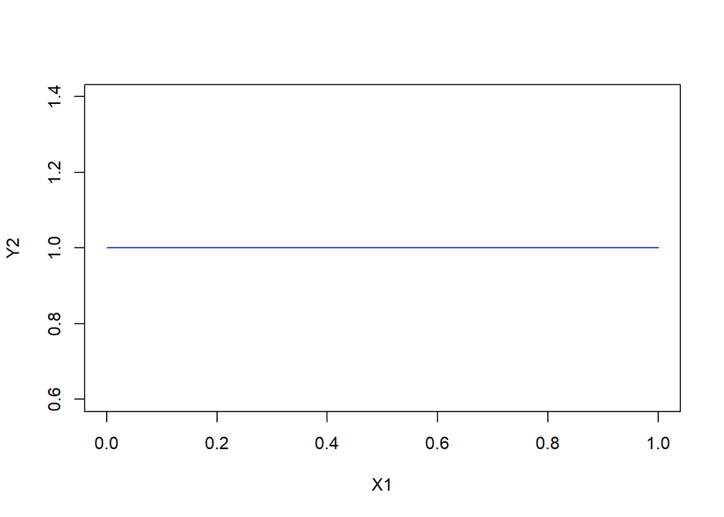

```r
plot2 <- plot(X1, Y2, type= 'l', col = 'blue')
lines(X1, g2, col = 'red')
```